# EDA

```python
import numpy as np
import pandas as pd
import matplotlib.pyplot as plt
import seaborn as sns
import os
%matplotlib inline
```

```python
os.chdir("D:\Mini Project\8. Random Forest and AdaBoost")
```

#### Reading the data set

```python
hre = pd.read_csv("HR_Employee_Attrition_Data.csv")
hre.head().T
```

|  | 0 | 1 | 2 | 3 | 4 |
| --- | --- | --- | --- | --- | --- |
| Age | 41 | 49 | 37 | 33 | 27 |
| Attrition | Yes | No | Yes | No | No |
| BusinessTravel | Travel_Rarely | Travel_Frequently | Travel_Rarely | Travel_Frequently | Travel_Rarely |
| DailyRate | 1102 | 279 | 1373 | 1392 | 591 |
| Department | Sales | Research & Development | Research & Development | Research & Development | Research & Development |
| DistanceFromHome | 1 | 8 | 2 | 3 | 2 |
| Education | 2 | 1 | 2 | 4 | 1 |
| EducationField | Life Sciences | Life Sciences | Other | Life Sciences | Medical |
| EmployeeCount | 1 | 1 | 1 | 1 | 1 |
| EmployeeNumber | 1 | 2 | 3 | 4 | 5 |
| EnvironmentSatisfaction | 2 | 3 | 4 | 4 | 1 |
| Gender | Female | Male | Male | Female | Male |
| HourlyRate | 94 | 61 | 92 | 56 | 40 |
| JobInvolvement | 3 | 2 | 2 | 3 | 3 |
| JobLevel | 2 | 2 | 1 | 1 | 1 |
| JobRole | Sales Executive | Research Scientist | Laboratory Technician | Research Scientist | Laboratory Technician |
| JobSatisfaction | 4 | 2 | 3 | 3 | 2 |
| MaritalStatus | Single | Married | Single | Married | Married |
| MonthlyIncome | 5993 | 5130 | 2090 | 2909 | 3468 |
| MonthlyRate | 19479 | 24907 | 2396 | 23159 | 16632 |
| NumCompaniesWorked | 8 | 1 | 6 | 1 | 9 |
| Over18 | Y | Y | Y | Y | Y |
| OverTime | Yes | No | Yes | Yes | No |
| PercentSalaryHike | 11 | 23 | 15 | 11 | 12 |
| PerformanceRating | 3 | 4 | 3 | 3 | 3 |
| RelationshipSatisfaction | 1 | 4 | 2 | 3 | 4 |
| StandardHours | 80 | 80 | 80 | 80 | 80 |
| StockOptionLevel | 0 | 1 | 0 | 0 | 1 |
| TotalWorkingYears | 8 | 10 | 7 | 8 | 6 |
| TrainingTimesLastYear | 0 | 3 | 3 | 3 | 3 |
| WorkLifeBalance | 1 | 3 | 3 | 3 | 3 |
| YearsAtCompany | 6 | 10 | 0 | 8 | 2 |
| YearsInCurrentRole | 4 | 7 | 0 | 7 | 2 |
| YearsSinceLastPromotion | 0 | 1 | 0 | 3 | 2 |
| YearsWithCurrManager | 5 | 7 | 0 | 0 | 2 |

```python
hre.shape
```

```
(2940, 35)
```

There are 35 columns and 2940 data entries in the file

```python
hre.dtypes
```

```
Age                          int64
Attrition                   object
BusinessTravel              object
DailyRate                    int64
Department                  object
DistanceFromHome             int64
Education                    int64
EducationField              object
EmployeeCount                int64
EmployeeNumber               int64
EnvironmentSatisfaction      int64
Gender                      object
HourlyRate                   int64
JobInvolvement               int64
JobLevel                     int64
JobRole                     object
JobSatisfaction              int64
MaritalStatus               object
MonthlyIncome                int64
MonthlyRate                  int64
NumCompaniesWorked           int64
Over18                      object
OverTime                    object
PercentSalaryHike            int64
PerformanceRating            int64
RelationshipSatisfaction     int64
StandardHours                int64
StockOptionLevel             int64
TotalWorkingYears            int64
TrainingTimesLastYear        int64
WorkLifeBalance              int64
YearsAtCompany               int64
YearsInCurrentRole           int64
YearsSinceLastPromotion      int64
YearsWithCurrManager         int64
dtype: object
```

#### Checking summary statistics

```python
hre.describe().T
```

|  | count | mean | std | min | 25% | 50% | 75% | max |
| --- | --- | --- | --- | --- | --- | --- | --- | --- |
| Age | 2940.0 | 36.923810 | 9.133819 | 18.0 | 30.00 | 36.0 | 43.00 | 60.0 |
| DailyRate | 2940.0 | 802.485714 | 403.440447 | 102.0 | 465.00 | 802.0 | 1157.00 | 1499.0 |
| DistanceFromHome | 2940.0 | 9.192517 | 8.105485 | 1.0 | 2.00 | 7.0 | 14.00 | 29.0 |
| Education | 2940.0 | 2.912925 | 1.023991 | 1.0 | 2.00 | 3.0 | 4.00 | 5.0 |
| EmployeeCount | 2940.0 | 1.000000 | 0.000000 | 1.0 | 1.00 | 1.0 | 1.00 | 1.0 |
| EmployeeNumber | 2940.0 | 1470.500000 | 848.849221 | 1.0 | 735.75 | 1470.5 | 2205.25 | 2940.0 |
| EnvironmentSatisfaction | 2940.0 | 2.721769 | 1.092896 | 1.0 | 2.00 | 3.0 | 4.00 | 4.0 |
| HourlyRate | 2940.0 | 65.891156 | 20.325969 | 30.0 | 48.00 | 66.0 | 84.00 | 100.0 |
| JobInvolvement | 2940.0 | 2.729932 | 0.711440 | 1.0 | 2.00 | 3.0 | 3.00 | 4.0 |
| JobLevel | 2940.0 | 2.063946 | 1.106752 | 1.0 | 1.00 | 2.0 | 3.00 | 5.0 |
| JobSatisfaction | 2940.0 | 2.728571 | 1.102658 | 1.0 | 2.00 | 3.0 | 4.00 | 4.0 |
| MonthlyIncome | 2940.0 | 6502.931293 | 4707.155770 | 1009.0 | 2911.00 | 4919.0 | 8380.00 | 19999.0 |
| MonthlyRate | 2940.0 | 14313.103401 | 7116.575021 | 2094.0 | 8045.00 | 14235.5 | 20462.00 | 26999.0 |
| NumCompaniesWorked | 2940.0 | 2.693197 | 2.497584 | 0.0 | 1.00 | 2.0 | 4.00 | 9.0 |
| PercentSalaryHike | 2940.0 | 15.209524 | 3.659315 | 11.0 | 12.00 | 14.0 | 18.00 | 25.0 |
| PerformanceRating | 2940.0 | 3.153741 | 0.360762 | 3.0 | 3.00 | 3.0 | 3.00 | 4.0 |
| RelationshipSatisfaction | 2940.0 | 2.712245 | 1.081025 | 1.0 | 2.00 | 3.0 | 4.00 | 4.0 |
| StandardHours | 2940.0 | 80.000000 | 0.000000 | 80.0 | 80.00 | 80.0 | 80.00 | 80.0 |
| StockOptionLevel | 2940.0 | 0.793878 | 0.851932 | 0.0 | 0.00 | 1.0 | 1.00 | 3.0 |
| TotalWorkingYears | 2940.0 | 11.279592 | 7.779458 | 0.0 | 6.00 | 10.0 | 15.00 | 40.0 |
| TrainingTimesLastYear | 2940.0 | 2.799320 | 1.289051 | 0.0 | 2.00 | 3.0 | 3.00 | 6.0 |
| WorkLifeBalance | 2940.0 | 2.761224 | 0.706356 | 1.0 | 2.00 | 3.0 | 3.00 | 4.0 |
| YearsAtCompany | 2940.0 | 7.008163 | 6.125483 | 0.0 | 3.00 | 5.0 | 9.00 | 40.0 |
| YearsInCurrentRole | 2940.0 | 4.229252 | 3.622521 | 0.0 | 2.00 | 3.0 | 7.00 | 18.0 |
| YearsSinceLastPromotion | 2940.0 | 2.187755 | 3.221882 | 0.0 | 0.00 | 1.0 | 3.00 | 15.0 |
| YearsWithCurrManager | 2940.0 | 4.123129 | 3.567529 | 0.0 | 2.00 | 3.0 | 7.00 | 17.0 |

#### Checking for missing values

```python
hre[hre.isnull().any(axis=1)]
```

|  | Age | Attrition | BusinessTravel | DailyRate | Department | DistanceFromHome | Education | EducationField | EmployeeCount | EmployeeNumber | ... | RelationshipSatisfaction | StandardHours | StockOptionLevel | TotalWorkingYears | TrainingTimesLastYear | WorkLifeBalance | YearsAtCompany | YearsInCurrentRole | YearsSinceLastPromotion | YearsWithCurrManager |
| --- | --- | --- | --- | --- | --- | --- | --- | --- | --- | --- | --- | --- | --- | --- | --- | --- | --- | --- | --- | --- | --- |

0 rows × 35 columns

There are no missing values

```python
hre.nunique()
```

```
Age                           43
Attrition                      2
BusinessTravel                 3
DailyRate                    886
Department                     3
DistanceFromHome              29
Education                      5
EducationField                 6
EmployeeCount                  1
EmployeeNumber              2940
EnvironmentSatisfaction        4
Gender                         2
HourlyRate                    71
JobInvolvement                 4
JobLevel                       5
JobRole                        9
JobSatisfaction                4
MaritalStatus                  3
MonthlyIncome               1349
MonthlyRate                 1427
NumCompaniesWorked            10
Over18                         1
OverTime                       2
PercentSalaryHike             15
PerformanceRating              2
RelationshipSatisfaction       4
StandardHours                  1
StockOptionLevel               4
TotalWorkingYears             40
TrainingTimesLastYear          7
WorkLifeBalance                4
YearsAtCompany                37
YearsInCurrentRole            19
YearsSinceLastPromotion       16
YearsWithCurrManager          18
dtype: int64
```

Here the value for columns, Over18, StandardHours and EmployeeCount same for all rows, we can eliminate these columns.

```python
del hre['EmployeeCount']
del hre['StandardHours']
del hre['Over18']
```

Ploting Histogram for various factors in the same plot space.

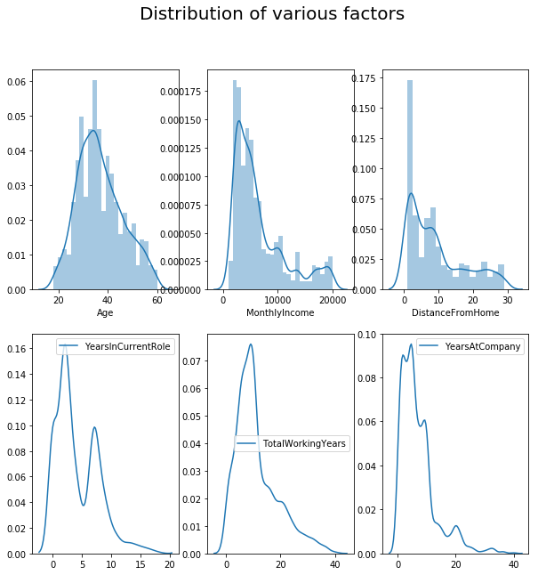

```python
fig,ax = plt.subplots(2,3, figsize=(10,10))
plt.suptitle("Distribution of various factors", fontsize=20)
sns.distplot(hre['Age'], ax = ax[0,0])
sns.distplot(hre['MonthlyIncome'], ax = ax[0,1])
sns.distplot(hre['DistanceFromHome'], ax = ax[0,2])
sns.kdeplot(hre['YearsInCurrentRole'], ax = ax[1,0])
sns.kdeplot(hre['TotalWorkingYears'], ax = ax[1,1])
sns.kdeplot(hre['YearsAtCompany'], ax = ax[1,2])
plt.show()
```

Checking the distribution of various factors

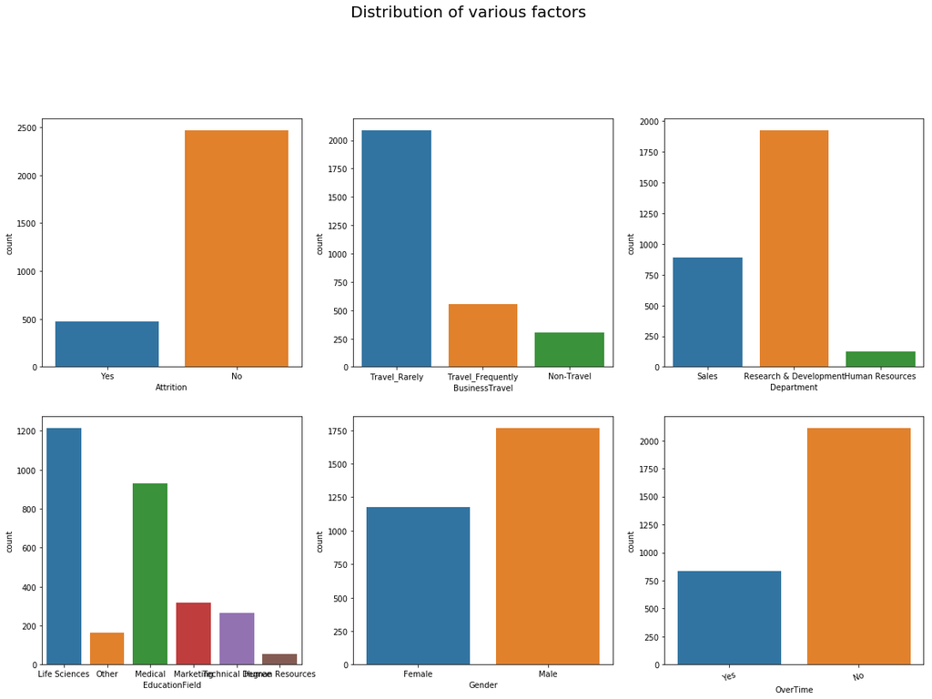

```python
fig,ax = plt.subplots(2,3, figsize=(20,20))
plt.suptitle("Distribution of various factors", fontsize=20)
sns.countplot(hre['Attrition'], ax = ax[0,0])
sns.countplot(hre['BusinessTravel'], ax = ax[0,1])
sns.countplot(hre['Department'], ax = ax[0,2])
sns.countplot(hre['EducationField'], ax = ax[1,0])
sns.countplot(hre['Gender'], ax = ax[1,1])
sns.countplot(hre['OverTime'], ax = ax[1,2])
plt.xticks(rotation=20)
plt.subplots_adjust(bottom=0.4)
plt.show()
```

In the data we have, Attrition data is not distributed equally in this

Checking gender wise distribution

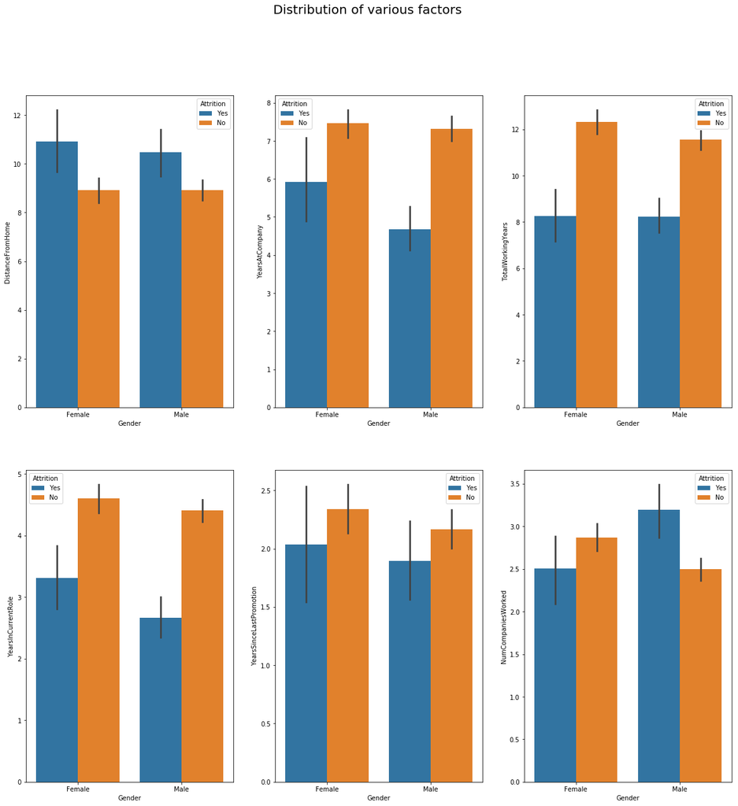

```python
fig,ax = plt.subplots(2,3, figsize=(20,20))
plt.suptitle("Distribution of various factors", fontsize=20)
sns.barplot(hre['Gender'],hre['DistanceFromHome'],hue = hre['Attrition'], ax = ax[0,0]);
sns.barplot(hre['Gender'],hre['YearsAtCompany'],hue = hre['Attrition'], ax = ax[0,1]);
sns.barplot(hre['Gender'],hre['TotalWorkingYears'],hue = hre['Attrition'], ax = ax[0,2]);
sns.barplot(hre['Gender'],hre['YearsInCurrentRole'],hue = hre['Attrition'], ax = ax[1,0]);
sns.barplot(hre['Gender'],hre['YearsSinceLastPromotion'],hue = hre['Attrition'], ax = ax[1,1]);
sns.barplot(hre['Gender'],hre['NumCompaniesWorked'],hue = hre['Attrition'], ax = ax[1,2]);
plt.show()
```

Ploting a correlation map for all numeric variables

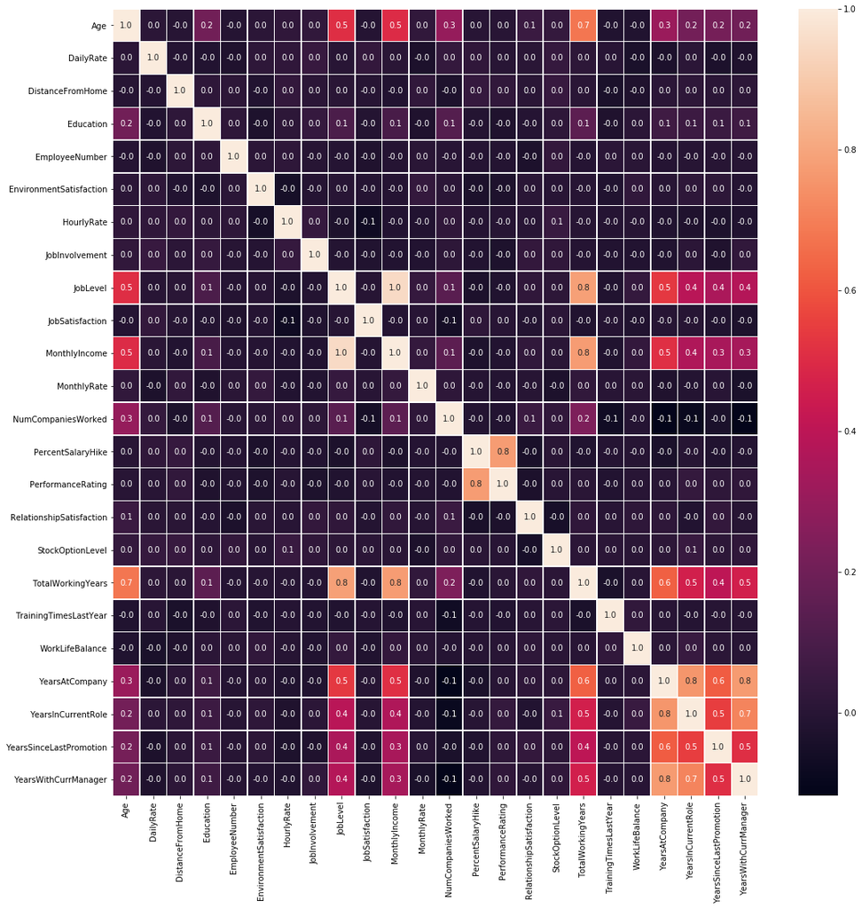

```python
f,ax = plt.subplots(figsize=(18, 18))
sns.heatmap(hre.corr(), annot=True, linewidths=.5, fmt= '.1f',ax=ax)
plt.show()
```

#### Converting Yes / No values in Attrition column to 1 / 0

```python
cleanup_nums = {"Attrition":     {"Yes": 1, "No": 0}}
```

```python
hre.replace(cleanup_nums, inplace=True)
hre.head()
```

|  | Age | Attrition | BusinessTravel | DailyRate | Department | DistanceFromHome | Education | EducationField | EmployeeNumber | EnvironmentSatisfaction | ... | PerformanceRating | RelationshipSatisfaction | StockOptionLevel | TotalWorkingYears | TrainingTimesLastYear | WorkLifeBalance | YearsAtCompany | YearsInCurrentRole | YearsSinceLastPromotion | YearsWithCurrManager |
| --- | --- | --- | --- | --- | --- | --- | --- | --- | --- | --- | --- | --- | --- | --- | --- | --- | --- | --- | --- | --- | --- |
| 0 | 41 | 1 | Travel_Rarely | 1102 | Sales | 1 | 2 | Life Sciences | 1 | 2 | ... | 3 | 1 | 0 | 8 | 0 | 1 | 6 | 4 | 0 | 5 |
| 1 | 49 | 0 | Travel_Frequently | 279 | Research & Development | 8 | 1 | Life Sciences | 2 | 3 | ... | 4 | 4 | 1 | 10 | 3 | 3 | 10 | 7 | 1 | 7 |
| 2 | 37 | 1 | Travel_Rarely | 1373 | Research & Development | 2 | 2 | Other | 3 | 4 | ... | 3 | 2 | 0 | 7 | 3 | 3 | 0 | 0 | 0 | 0 |
| 3 | 33 | 0 | Travel_Frequently | 1392 | Research & Development | 3 | 4 | Life Sciences | 4 | 4 | ... | 3 | 3 | 0 | 8 | 3 | 3 | 8 | 7 | 3 | 0 |
| 4 | 27 | 0 | Travel_Rarely | 591 | Research & Development | 2 | 1 | Medical | 5 | 1 | ... | 3 | 4 | 1 | 6 | 3 | 3 | 2 | 2 | 2 | 2 |

5 rows × 32 columns

#### Splitting to training and testing data

```python
from sklearn.cross_validation import train_test_split
import random
```

```python
np.random.seed(40)
train,test = train_test_split( hre, test_size = 0.3)
```

Checking distribution of Attribution in each group

```python
hre.Attrition.value_counts()
```

```
0    2466
1     474
Name: Attrition, dtype: int64
```

```python
474/(2466+474)
```

```
0.16122448979591836
```

```python
test.Attrition.value_counts()
```

```
0    742
1    140
Name: Attrition, dtype: int64
```

```python
140/(140+742)
```

```
0.15873015873015872
```

```python
train.Attrition.value_counts()
```

```
0    1724
1     334
Name: Attrition, dtype: int64
```

```python
334/(334+1724)
```

```
0.16229348882410108
```

Split of attribution is same for both train and test data

#### Spliting target variable and independent variables

```python
X1 =  train[['Age', 'BusinessTravel', 'DailyRate', 'Department',
       'DistanceFromHome', 'Education', 'EducationField',
       'EnvironmentSatisfaction', 'Gender', 'HourlyRate', 'JobInvolvement',
       'JobLevel', 'JobRole', 'JobSatisfaction', 'MaritalStatus',
       'MonthlyIncome', 'MonthlyRate', 'NumCompaniesWorked', 'OverTime',
       'PercentSalaryHike', 'PerformanceRating', 'RelationshipSatisfaction',
       'StockOptionLevel', 'TotalWorkingYears', 'TrainingTimesLastYear',
       'WorkLifeBalance', 'YearsAtCompany', 'YearsInCurrentRole',
       'YearsSinceLastPromotion', 'YearsWithCurrManager']]
X2 =  test[['Age', 'BusinessTravel', 'DailyRate', 'Department',
       'DistanceFromHome', 'Education', 'EducationField',
       'EnvironmentSatisfaction', 'Gender', 'HourlyRate', 'JobInvolvement',
       'JobLevel', 'JobRole', 'JobSatisfaction', 'MaritalStatus',
       'MonthlyIncome', 'MonthlyRate', 'NumCompaniesWorked', 'OverTime',
       'PercentSalaryHike', 'PerformanceRating', 'RelationshipSatisfaction',
       'StockOptionLevel', 'TotalWorkingYears', 'TrainingTimesLastYear',
       'WorkLifeBalance', 'YearsAtCompany', 'YearsInCurrentRole',
       'YearsSinceLastPromotion', 'YearsWithCurrManager']]
```

```python
y_train = train["Attrition"]
y_test = test["Attrition"]
```

#### Categorical Variable to Numerical Variables

```python
X_train = pd.get_dummies(X1)
X_test = pd.get_dummies(X2)
X_train.columns
```

```
Index(['Age', 'DailyRate', 'DistanceFromHome', 'Education',
       'EnvironmentSatisfaction', 'HourlyRate', 'JobInvolvement', 'JobLevel',
       'JobSatisfaction', 'MonthlyIncome', 'MonthlyRate', 'NumCompaniesWorked',
       'PercentSalaryHike', 'PerformanceRating', 'RelationshipSatisfaction',
       'StockOptionLevel', 'TotalWorkingYears', 'TrainingTimesLastYear',
       'WorkLifeBalance', 'YearsAtCompany', 'YearsInCurrentRole',
       'YearsSinceLastPromotion', 'YearsWithCurrManager',
       'BusinessTravel_Non-Travel', 'BusinessTravel_Travel_Frequently',
       'BusinessTravel_Travel_Rarely', 'Department_Human Resources',
       'Department_Research & Development', 'Department_Sales',
       'EducationField_Human Resources', 'EducationField_Life Sciences',
       'EducationField_Marketing', 'EducationField_Medical',
       'EducationField_Other', 'EducationField_Technical Degree',
       'Gender_Female', 'Gender_Male', 'JobRole_Healthcare Representative',
       'JobRole_Human Resources', 'JobRole_Laboratory Technician',
       'JobRole_Manager', 'JobRole_Manufacturing Director',
       'JobRole_Research Director', 'JobRole_Research Scientist',
       'JobRole_Sales Executive', 'JobRole_Sales Representative',
       'MaritalStatus_Divorced', 'MaritalStatus_Married',
       'MaritalStatus_Single', 'OverTime_No', 'OverTime_Yes'],
      dtype='object')
```

#### Fitting Random Forest

Scaling the data

```python
from sklearn.preprocessing import StandardScaler
sc = StandardScaler()
X_train = sc.fit_transform(X_train)
X_test = sc.transform(X_test)
```

```python
from sklearn.ensemble import RandomForestClassifier
```

```python
model = RandomForestClassifier()
```

```python
model.fit(X_train,y_train)
```

```
RandomForestClassifier(bootstrap=True, class_weight=None, criterion='gini',
            max_depth=None, max_features='auto', max_leaf_nodes=None,
            min_impurity_decrease=0.0, min_impurity_split=None,
            min_samples_leaf=1, min_samples_split=2,
            min_weight_fraction_leaf=0.0, n_estimators=10, n_jobs=1,
            oob_score=False, random_state=None, verbose=0,
            warm_start=False)
```

```python
pred_y_train = model.predict(X_train)
pred_y_train
```

```
array([0, 1, 0, ..., 0, 1, 1], dtype=int64)
```

#### Let us see the classification accuracy of our model

```python
from sklearn.metrics import accuracy_score
score = accuracy_score(y_train, pred_y_train)
score
```

```
0.9980563654033042
```

#### AUC

```python
from sklearn.metrics import roc_curve
from sklearn.metrics import auc,confusion_matrix

y_train_prob = model.predict_proba(X_train)
fpr, tpr, thresholds =  roc_curve(y_train, y_train_prob[:,1])
auc(fpr, tpr)
```

```
0.9999852383400252
```

#### Checking for Test data

```python
pred_y_test = model.predict(X_test)
pred_y_test

## Let us see the classification accuracy of our model
score_test = accuracy_score(y_test, pred_y_test)
score_test
```

```
0.9523809523809523
```

```python
y_test_prob = model.predict_proba(X_test)
fpr, tpr, thresholds =  roc_curve(y_test, y_test_prob[:,1])
auc(fpr, tpr)
```

```
0.9403686946476704
```

```python
from sklearn import model_selection
scores = model_selection.cross_val_score(model, X_train, y_train, cv = 10, scoring='roc_auc')
scores.mean()
```

```
0.9426960970019017
```

```python
scores.std()
```

```
0.029527590209402408
```

So by cross validation we get the correct AUC of the model, that is 94.26% is the correct AUC with standard deviation of 0.029. For test data it is almost same, but auc for training data is high. so the model is overfitted. Need to tune the model.

#### Checking important variables

```python
import pandas as pd
feature_imp = pd.Series(model.feature_importances_,index= ['Age', 'DailyRate', 'DistanceFromHome', 'Education',
       'EnvironmentSatisfaction', 'HourlyRate', 'JobInvolvement', 'JobLevel',
       'JobSatisfaction', 'MonthlyIncome', 'MonthlyRate', 'NumCompaniesWorked',
       'PercentSalaryHike', 'PerformanceRating', 'RelationshipSatisfaction',
       'StockOptionLevel', 'TotalWorkingYears', 'TrainingTimesLastYear',
       'WorkLifeBalance', 'YearsAtCompany', 'YearsInCurrentRole',
       'YearsSinceLastPromotion', 'YearsWithCurrManager',
       'BusinessTravel_Non-Travel', 'BusinessTravel_Travel_Frequently',
       'BusinessTravel_Travel_Rarely', 'Department_Human Resources',
       'Department_Research & Development', 'Department_Sales',
       'EducationField_Human Resources', 'EducationField_Life Sciences',
       'EducationField_Marketing', 'EducationField_Medical',
       'EducationField_Other', 'EducationField_Technical Degree',
       'Gender_Female', 'Gender_Male', 'JobRole_Healthcare Representative',
       'JobRole_Human Resources', 'JobRole_Laboratory Technician',
       'JobRole_Manager', 'JobRole_Manufacturing Director',
       'JobRole_Research Director', 'JobRole_Research Scientist',
       'JobRole_Sales Executive', 'JobRole_Sales Representative',
       'MaritalStatus_Divorced', 'MaritalStatus_Married',
       'MaritalStatus_Single', 'OverTime_No', 'OverTime_Yes'] ).sort_values(ascending=False)
feature_imp
```

```
MonthlyIncome                        0.075613
Age                                  0.065455
DailyRate                            0.061138
TotalWorkingYears                    0.054012
HourlyRate                           0.047112
DistanceFromHome                     0.044539
MonthlyRate                          0.043385
OverTime_Yes                         0.042346
YearsAtCompany                       0.038872
EnvironmentSatisfaction              0.032238
YearsSinceLastPromotion              0.029779
PercentSalaryHike                    0.028975
NumCompaniesWorked                   0.027408
JobSatisfaction                      0.027171
OverTime_No                          0.026457
YearsWithCurrManager                 0.026312
YearsInCurrentRole                   0.024383
MaritalStatus_Single                 0.023750
StockOptionLevel                     0.023114
RelationshipSatisfaction             0.019975
JobLevel                             0.019408
Education                            0.019306
WorkLifeBalance                      0.017948
JobInvolvement                       0.017868
TrainingTimesLastYear                0.016998
Department_Sales                     0.012958
JobRole_Laboratory Technician        0.012681
BusinessTravel_Travel_Frequently     0.012041
JobRole_Sales Executive              0.009062
Gender_Male                          0.008495
Gender_Female                        0.008308
MaritalStatus_Divorced               0.007447
BusinessTravel_Travel_Rarely         0.007328
EducationField_Life Sciences         0.006620
BusinessTravel_Non-Travel            0.006463
EducationField_Technical Degree      0.006430
EducationField_Medical               0.005653
JobRole_Sales Representative         0.005293
EducationField_Marketing             0.005062
MaritalStatus_Married                0.004989
JobRole_Research Scientist           0.004739
Department_Research & Development    0.004585
JobRole_Healthcare Representative    0.003435
PerformanceRating                    0.003057
Department_Human Resources           0.002189
JobRole_Manager                      0.002105
EducationField_Other                 0.001849
EducationField_Human Resources       0.001826
JobRole_Human Resources              0.001667
JobRole_Manufacturing Director       0.001510
JobRole_Research Director            0.000645
dtype: float64
```

```
No handles with labels found to put in legend.
```

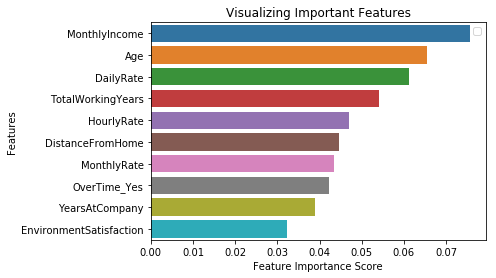

```python
import matplotlib.pyplot as plt
import seaborn as sns
%matplotlib inline
# Creating a bar plot
feature_imp=feature_imp[0:10,]

sns.barplot(x=feature_imp, y=feature_imp.index)
# Add labels to your graph
plt.xlabel('Feature Importance Score')
plt.ylabel('Features')
plt.title("Visualizing Important Features")
plt.legend()
plt.show()
```

Here most important variable is MonthlyIncome followed by Age and Daily rate

#### Parameter Tuning

```python
import time
from sklearn.grid_search import GridSearchCV
```

```python
np.random.seed(42)
start = time.time()

param_dist = {

              'n_estimators':np.arange(10,20),
              'max_depth': [2, 3, 4],
              'bootstrap': [True, False],
              'max_features': ['auto', 'sqrt', 'log2', None],
              'criterion': ['gini', 'entropy']}

cv_rf = GridSearchCV(model, cv = 10,
                     param_grid=param_dist,
                     n_jobs = 3)

cv_rf.fit(X_train, y_train)
print('Best Parameters using grid search: \n',
      cv_rf.best_params_)
end = time.time()
print('Time taken in grid search: {0: .2f}'.format(end - start))
```

```
Best Parameters using grid search:
 {'bootstrap': True, 'criterion': 'gini', 'max_depth': 4, 'max_features': None, 'n_estimators': 14}
Time taken in grid search:  208.40
```

```python
classifier = cv_rf.best_estimator_
classifier.fit(X_train,y_train)
```

```
RandomForestClassifier(bootstrap=True, class_weight=None, criterion='gini',
            max_depth=4, max_features=None, max_leaf_nodes=None,
            min_impurity_decrease=0.0, min_impurity_split=None,
            min_samples_leaf=1, min_samples_split=2,
            min_weight_fraction_leaf=0.0, n_estimators=14, n_jobs=1,
            oob_score=False, random_state=None, verbose=0,
            warm_start=False)
```

#### AUC

```python
y_train_prob = classifier.predict_proba(X_train)
fpr, tpr, thresholds = roc_curve(y_train, y_train_prob[:,1])
auc_d = auc(fpr, tpr)
auc_d
```

```
0.8810540172555121
```

```python
y_test_prob = classifier.predict_proba(X_test)
fpr, tpr, thresholds = roc_curve(y_test, y_test_prob[:,1])
auc_h = auc(fpr, tpr)
auc_h
```

```
0.8063631112822487
```

```python
Prediction = classifier.predict_proba(X_train)
train["prob_score"] = Prediction[:,1]
```

#### scoring and rank ordering

decile code

```python
def deciles(x):
    decile = pd.Series(index=[0,1,2,3,4,5,6,7,8,9])
    for i in np.arange(0.1,1.1,0.1):
        decile[int(i*10)]=x.quantile(i)
    def z(x):
        if x<decile[1]: return(1)
        elif x<decile[2]: return(2)
        elif x<decile[3]: return(3)
        elif x<decile[4]: return(4)
        elif x<decile[5]: return(5)
        elif x<decile[6]: return(6)
        elif x<decile[7]: return(7)
        elif x<decile[8]: return(8)
        elif x<decile[9]: return(9)
        elif x<=decile[10]: return(10)
        else:return(np.NaN)
    s=x.map(z)
    return(s)
```

```python
def Rank_Ordering(X,y,Target):
    X['decile']=deciles(X[y])
    Rank=X.groupby('decile').apply(lambda x: pd.Series([
        np.min(x[y]),
        np.max(x[y]),
        np.mean(x[y]),
        np.size(x[y]),
        np.sum(x[Target]),
        np.size(x[Target][x[Target]==0]),
        ],
        index=(["min_resp","max_resp","avg_resp",
                "cnt","cnt_resp","cnt_non_resp"])
        )).reset_index()
    Rank = Rank.sort_values(by='decile',ascending=False)
    Rank["rrate"] = Rank["cnt_resp"]*100/Rank["cnt"]
    Rank["cum_resp"] = np.cumsum(Rank["cnt_resp"])
    Rank["cum_non_resp"] = np.cumsum(Rank["cnt_non_resp"])
    Rank["cum_resp_pct"] = Rank["cum_resp"]/np.sum(Rank["cnt_resp"])
    Rank["cum_non_resp_pct"]=Rank["cum_non_resp"]/np.sum(Rank["cnt_non_resp"])
    Rank["KS"] = Rank["cum_resp_pct"] - Rank["cum_non_resp_pct"]
    Rank
    return(Rank)
```

Rank ordering for train data

```python
Rank = Rank_Ordering(train,"prob_score","Attrition")
Rank
```

|  | decile | min_resp | max_resp | avg_resp | cnt | cnt_resp | cnt_non_resp | rrate | cum_resp | cum_non_resp | cum_resp_pct | cum_non_resp_pct | KS |
| --- | --- | --- | --- | --- | --- | --- | --- | --- | --- | --- | --- | --- | --- |
| 9 | 10 | 0.390606 | 0.879506 | 0.591774 | 207.0 | 160.0 | 47.0 | 77.294686 | 160.0 | 47.0 | 0.479042 | 0.027262 | 0.451780 |
| 8 | 9 | 0.192982 | 0.390106 | 0.276987 | 206.0 | 77.0 | 129.0 | 37.378641 | 237.0 | 176.0 | 0.709581 | 0.102088 | 0.607493 |
| 7 | 8 | 0.137881 | 0.190658 | 0.161077 | 205.0 | 32.0 | 173.0 | 15.609756 | 269.0 | 349.0 | 0.805389 | 0.202436 | 0.602953 |
| 6 | 7 | 0.110535 | 0.137434 | 0.125123 | 202.0 | 27.0 | 175.0 | 13.366337 | 296.0 | 524.0 | 0.886228 | 0.303944 | 0.582283 |
| 5 | 6 | 0.096947 | 0.110406 | 0.103958 | 209.0 | 7.0 | 202.0 | 3.349282 | 303.0 | 726.0 | 0.907186 | 0.421114 | 0.486072 |
| 4 | 5 | 0.089683 | 0.096740 | 0.091946 | 248.0 | 8.0 | 240.0 | 3.225806 | 311.0 | 966.0 | 0.931138 | 0.560325 | 0.370813 |
| 3 | 4 | 0.081778 | 0.089658 | 0.084924 | 171.0 | 11.0 | 160.0 | 6.432749 | 322.0 | 1126.0 | 0.964072 | 0.653132 | 0.310940 |
| 2 | 3 | 0.064731 | 0.081753 | 0.069797 | 222.0 | 3.0 | 219.0 | 1.351351 | 325.0 | 1345.0 | 0.973054 | 0.780162 | 0.192891 |
| 1 | 2 | 0.050255 | 0.064577 | 0.053025 | 378.0 | 9.0 | 369.0 | 2.380952 | 334.0 | 1714.0 | 1.000000 | 0.994200 | 0.005800 |
| 0 | 1 | 0.049385 | 0.049385 | 0.049385 | 10.0 | 0.0 | 10.0 | 0.000000 | 334.0 | 1724.0 | 1.000000 | 1.000000 | 0.000000 |

Response rate in top deciles is 77.29% and Highest ks value 60.74%. This looks bit overfitting.

Rank ordering for test data

```python
Prediction_h = classifier.predict_proba(X_test)
test["prob_score"] = Prediction_h[:,1]

Rank_h = Rank_Ordering(test,"prob_score","Attrition")
Rank_h
```

|  | decile | min_resp | max_resp | avg_resp | cnt | cnt_resp | cnt_non_resp | rrate | cum_resp | cum_non_resp | cum_resp_pct | cum_non_resp_pct | KS |
| --- | --- | --- | --- | --- | --- | --- | --- | --- | --- | --- | --- | --- | --- |
| 9 | 10 | 0.370074 | 0.860681 | 0.551105 | 90.0 | 65.0 | 25.0 | 72.222222 | 65.0 | 25.0 | 0.464286 | 0.033693 | 0.430593 |
| 8 | 9 | 0.202872 | 0.368782 | 0.280854 | 87.0 | 22.0 | 65.0 | 25.287356 | 87.0 | 90.0 | 0.621429 | 0.121294 | 0.500135 |
| 7 | 8 | 0.147326 | 0.202796 | 0.170456 | 89.0 | 13.0 | 76.0 | 14.606742 | 100.0 | 166.0 | 0.714286 | 0.223720 | 0.490566 |
| 6 | 7 | 0.117484 | 0.147301 | 0.131397 | 88.0 | 8.0 | 80.0 | 9.090909 | 108.0 | 246.0 | 0.771429 | 0.331536 | 0.439892 |
| 5 | 6 | 0.099271 | 0.116056 | 0.106342 | 88.0 | 7.0 | 81.0 | 7.954545 | 115.0 | 327.0 | 0.821429 | 0.440701 | 0.380728 |
| 4 | 5 | 0.089683 | 0.098883 | 0.092762 | 113.0 | 8.0 | 105.0 | 7.079646 | 123.0 | 432.0 | 0.878571 | 0.582210 | 0.296361 |
| 3 | 4 | 0.081778 | 0.089383 | 0.085129 | 65.0 | 3.0 | 62.0 | 4.615385 | 126.0 | 494.0 | 0.900000 | 0.665768 | 0.234232 |
| 2 | 3 | 0.064731 | 0.081753 | 0.069442 | 114.0 | 5.0 | 109.0 | 4.385965 | 131.0 | 603.0 | 0.935714 | 0.812668 | 0.123046 |
| 1 | 2 | 0.050255 | 0.062010 | 0.052866 | 146.0 | 9.0 | 137.0 | 6.164384 | 140.0 | 740.0 | 1.000000 | 0.997305 | 0.002695 |
| 0 | 1 | 0.049385 | 0.049385 | 0.049385 | 2.0 | 0.0 | 2.0 | 0.000000 | 140.0 | 742.0 | 1.000000 | 1.000000 | 0.000000 |

Here on testing the model on test data we are getting KS value of 50% and response rate of 72.22% in the top decile. This looks very good but compared to the training data this is less. The model looks bit over fitted.